# The Basics of R

Ahmad Abdel-Azim

December 23, 2018

## About the R Language

- R is an interpreted language, not a compiled one, meaning that all commands typed on the keyboard are directly executed without requiring to build a complete program like in most computer languages (C, Fortran, Pascal,…).
- Intuitive syntax
- When R is running, *variables*, *data*, *functions*, *results*, etc, are stored in the active memory of the computer in the form of *objects* which have a *name*.
- The user can do actions on these objects with *operators* (arithmetic, logical, comparison, . . .) and *functions* (which are themselves objects).

## Help Pages

- When unsure how to use a function or operator, look it up in the help pages (i.e. `?lm`, which will display the help page for the linear model function).
- **Description:** provides a brief description.
- **Usage**: for a function, gives the name with all its arguments and the possible options (with the corresponding default values); for an operator gives the typical use.
- **Arguments:** for a function, details each of its arguments.
- **Details:** detailed description.
- **Value:** if applicable, the type of object returned by the function or the operator.
- **See Also:** other help pages close or similar to the present one.
- **Examples:** some examples which can generally be executed without opening the help with the function `example`.

# **Data in R**

## Objects in R

- Objects in R have two *intrinsic attributes*: **mode** and **length**
- The mode is the basic type of the elements of the object.
- Four main modes: numeric, character, complex, and logical (FALSE or TRUE)
- The length is the number of elements of the object
- To display the mode, use `mode()` and to dsiplay the length, use `length()`

## More on Mode…

- A value of mode character is input with double quotes “. It is possible to include a quote in the value if it follows a backslash.

```r
x <- "Ahmad has \"good\" grades"
cat(x)
```

```
## Ahmad has "good" grades
```

- The following table gives an overview of the type of objects representing data.

Overview of the type of objects representing data.

| Object | Modes | Several.modes.possible. |
| --- | --- | --- |
| vector | numeric, character, complex, or logical | No |
| factor | numeric or character | No |
| array | numeric, character, complex, or logical | No |
| matrix | numeric, character, complex, or logical | No |
| data frame | numeric, character, complex, or logical | Yes |
| ts | numeric, character, complex, or logical | No |
| list | numeric, character, complex, logical, function, expression, | Yes |

## Types of Objects

- **Vector:** a variable in the commonly admitted meaning
- **Factor:** a categorical variable
- **Array:** a table with *k* dimensions
- **Matrix:** a particular case of array with k = 2 (Note that the elements of an array or of a matrix are all of the same mode)
- **Data frame:** a table composed with one or several vectors and/or factors all of the same length but possibly of different modes
- **ts:** a time series data set, containing additional attributes such as frequency and dates - - **List:** can contain any type of object, including lists
- For some objects, information other than mode and length is necessary to describe the data and it is given by *non-intrinsic* attributes. Among these attributes, we can cite `dim()` which corresponds to the dimensions of an object.

## Converting objects

- To convert an object from a type to another, changing some of its attributes, use a functions of the type `as.something` (i.e. `as.numeric()`).
- The following table summarizes common conversions…

Object conversions.

[output not shown]

## Working Directories in R

- The default behavior of R for the handling of .RData files and workspaces encourages and facilitates a model of breaking work contexts into distinct working directories.
- To change the working directory, use `setwd()` and include the folder path in the parantheses (in quotes).
- To check the current working directory use `getwd()` and include the folder path in the parantheses (in quotes).
- RStudio *projects* make it straightforward to divide work into multiple contexts, each with their own working directory, workspace, history, and source documents.
- To import data into R, use `read.csv()` or `read.table()` and include the file path (in quotes) inside the parentheses.

## Generating Data in R

- **Regular sequence** (examples)..
- `1:30`
- `seq(length=9, from=1, to=5)`
- `c(1, 1.5, 2, 2.5, 3, 3.5, 4, 4.5, 5)`
- `rep(1, 30)` or `gl(3, 5, length=30)`
- **Random sequences**: all functions are of the form `rfunc(n, p1, p2, ...)`, where *func* indicates the probability distribution, *n* the number of data generated, and *p1, p2,…* are the values of the parameters of the distribution (examples: `rnorm()`, `runif()`)
- Most of these functions have counterparts obtained by replacing the letter *r* with…
- *d* to get the probability density `dfunc(x, ...)`
- *p* to get the cumulative probability density `pfunc(x, ...)`
- *q* to get the value of quantile `qfunc(p, ...)`, with 0 < p < 1.
- The table below gives the details for each distribution, and the possible default values…

Types of distributions in R.

| Law | Function |
| --- | --- |
| Gaussian (normal) | rnorm(n, mean=0, sd=1) |
| Exponential | rexp(n, rate=1) |
| Gamma | rgamma(n, shape, scale=1) |
| Poisson | rpois(n, lambda) |
| Weibull | rweibull(n, shape, scale=1) |
| Cauchy | rcauchy(n, location=0, scale=1) |
| Beta | rbeta(n, shape1, shape2) |
| ‘Student’ (t) | rt(n, df) |
| Fisher-Snedecor (F) | rf(n, df1, df2) |
| Pearson (?2) | rchisq(n, df) |
| Binomial | rbinom(n, size, prob) |
| Multinomial | rmultinom(n, size, prob) |
| Geometric | rgeom(n, prob) |
| Hypergeometric | rhyper(nn, m, n, k) |
| Logistic | rlogis(n, location=0, scale=1) |
| Lognormal | rlnorm(n, meanlog=0, sdlog=1) |
| Negative binomial | rnbinom(n, size, prob) |
| Uniform | runif(n, min=0, max=1) |
| Wilcoxin’s statistics | rwilcox(nn, m, n), rsignrank(nn, n) |

## Operators in R

- There are three types of operators in R: *arithmetic*, *comparison*, and *logical*.

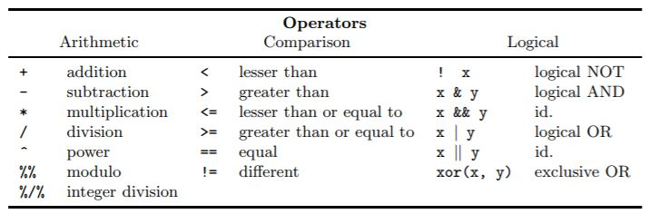

- The arithmetic and comparison operators act on two elements.
- The arithmetic operators act on variables of mode numeric, complex, or logical variables (logical values are coerced into numeric).
- The comparison operators may be applied to any mode and returns one or several logical values.
- The logical operators are applied to one or two objects of mode logical, and return one (or several) logical values.

## Accessing the values of an object: the indexing system

- The indexing system is an efficient and flexible way to access selectively the elements of an object; it can be either numeric or logical.
- Use **brackets** to refer to and index.
- For example…

```r
x <- 1:5
x
```

```
## [1] 1 2 3 4 5
```

```r
x[3] <- 20
x
```

```
## [1]  1  2 20  4  5
```

## Matrices

- For matrices, the indexing system can also be used; however, columns or rows must be specified.
- R has facilities for matrix computation and manipulation. The functions `rbind()` and `cbind()` matrices with respect to the lines or the columns, respectively.

# **Graphics in R**

## Managing Graphical Devices

- When a graphical function is executed, if no graphical device is open, R opens a graphical window and displays the graph. The list of available graphical devices depends on the operating system. One can open a graphical window with the command `x11()`.
- The list of available graphical devices can be found with `?device`.
- To change the active device, use `dev.set()` with the number of the active device in the parentheses.
- To close all graohical devices, use `dev.off()`.

## Low-level plotting commands

- R has a set of graphical functions which affect an already existing graph; they are called *low-level plotting commands*.
- Here are some common ones…
- `points(x, y)`
- `lines(x, y)`
- `text(x, y, labels,...)`
- `segments(x0, y0, x1, y1)`
- `abline(a, b)`
- `legend(x, y, legend)`

## Graphical parameters

- The presentation of graphics in R can be improved with graphical parameters.
- They can be used either as options of graphic functions (but it does not work for all), or with the function `par()` to change permanently the graphical parameters.
- An exhaustive list of such garphical parameters are available on the par help page (`?par`).
- Common ones include: `col`, `lwd`, `lty`, `mfrow`, `pch`
- An example of plot using several graphical parameters…

[output not shown]

# **Statistical Analyses in R**

## Linear Models

- Basic structure: `lm(y ~ x + z)` (read as *Predict y from the additive effects of x and of z*)
- To account for the interactions between *x* and *z*, use `lm(y ~ x:z)`
- To account for the interactions between *x* and *z* as well as their additive effects, use `lm(y ~ x*z)` (identical to `lm (y ~ x + Z + x:z)`).
- To account for the quadratic effects, cubic effects,… nth-degree effects of a factor, use `lm(y ~ x + ploy(z, n))`.
- To account for the effects of b, which are nested in a, use `lm(y ~ x %in% z)` (identical to `x+x:z`, or `x/z`).
- To remove the effect of a factor, use `lm(y ~ x*z - x:z)` (identical to `x + z`).
- The functions that we can use subsequently to extract the results (from any class of statistical function output) are called *generic* functions.
- The table below summarizes some common generic functions…

Generic Functions in R.

| Function | Description |
| --- | --- |
| print | returns a brief summary |
| summary | returns a detailed summary |
| df.residual | returns the number of residual degrees of freedom |
| coef | returns the estimated coefficients (sometimes with their standard-errors) |
| residuals | returns the residuals |
| deviance | returns the deviance |
| fitted | returns the fitted values |
| logLik | computes the logarithm of the likelihood and the number of parameters |
| AIC | computes the Akaike information criterion or AIC (depends on logLik()) |

## Supplementary Analyses

- Some generic functions do supplementary analyses from an object resulting from an analysis
- Usually that object is the main argument, but in some cases a further arguments are necessary.
- The `predict()` function can be used, for example, to compute the predicted values for new data from a fitted linear model.
- `Predict()` can be used in data visualization (i.e. to plot a linear model.)

## Packages in R

- To install packages into R, use `install.packages(" ")` and type the name of the package into the paranthses (in quotes).
- To load this installed package, use `library()` and include the package name within the parentheses.
- To update all packages within R, use `update.packages()`.

# **Programming with R in Practice**

## Loops and vectorization

- Looping is simply automating a multi-step process by organizing sequences of actions or âbatchâ processes and by grouping the parts that need to be repeated.
- Common types of loops: *for* loop and *while* loop.

## For loops

- Format example…

```
# Create a vector filled with random normal values
u1 <- rnorm(30)
print("This loop calculates the square of the first 10 elements of vector u1")

# Initialize usq
usq <- 0

for(i in 1:10) {
  # i-th element of `u1` squared into `i`-th position of `usq`
  usq[i] <- u1[i]*u1[i]
  print(usq[i])
}

print(i)
```

- For loops can also be nested.

## While loops

- The while loop is made of an initialization block, followed by a logical condition. This condition is typically expressed by the comparison between a control variable and a value, but any expression that evaluates to a logical value (True or False) is legitimate.
- If the result is FALSE, the loop is never executed.
- If the results is TRUE, the instruction or block of instructions is executed.
- Format example…

```
# Your User Defined Function
readinteger <- function(){
  n <- readline(prompt="Please, enter your ANSWER: ")
}

response <- as.integer(readinteger())

while (response != 42) {
  print("Sorry, the answer to whatever the question MUST be 42")
  response <- as.integer(readinteger())
}
```

- The `break` statement can be used to exit from a loop.
- The `next` statement discontinues a particular iteration and jumps to the next cycle.

## Further Explanations

[Link](https://cran.r-project.org/doc/contrib/Paradis-rdebuts_en.pdf) to pdf of *R for Beginners*.